# Gene_anno

Tina Gorsek Sparovec

26.1.22

```r
library(tidyverse)
require(org.Hs.eg.db)
library(janitor)
library(topGO)
library(ALL)
library(pcaExplorer)
if (!require("BiocManager", quietly = TRUE))
    install.packages("BiocManager")
library(enrichplot)

#BiocManager::install("hgu95av2.db")

# Required data: from notebook 1.0_metadata_exploration

# (1) subtraction/subset of the results_PAS_Ctrl and results_CtrlMus_Ctrl

results_PAS_ctrl
```

|  | baseMean | log2FoldChange | lfcSE | stat | pvalue | padj | weight |
| --- | --- | --- | --- | --- | --- | --- | --- |
| ENSG00000223572.10 | 2.550976e+00 | 29.5897738 | 2.4316208 | 12.168745 | 4.560391e-34 | 2.186191e-28 | 0.04840352 |
| ENSG00000135346 | 1.757736e+02 | 4.3426749 | 0.5491854 | 7.907485 | 2.626408e-15 | 1.779060e-11 | 1.71279091 |
| ENSG00000287260 | 1.256115e+00 | 24.9532701 | 3.0782104 | 8.106421 | 5.213245e-16 | 8.561603e-11 | 0.04709715 |
| ENSG00000105825 | 2.413937e+02 | 3.2869352 | 0.4345496 | 7.564005 | 3.908446e-14 | 1.215487e-10 | 1.86533413 |
| ENSG00000134107 | 2.282080e+02 | 2.6302086 | 0.3543304 | 7.423040 | 1.144625e-13 | 2.847735e-10 | 1.86533413 |
| ENSG00000060718 | 1.097791e+02 | 4.6138451 | 0.6212789 | 7.426367 | 1.116212e-13 | 3.023049e-10 | 1.42794986 |
| ENSG00000166106 | 8.389318e+01 | -2.1940429 | 0.3038147 | -7.221649 | 5.136108e-13 | 1.043264e-09 | 1.42794986 |
| ENSG00000189058 | 1.240347e+03 | -1.8518954 | 0.2598673 | -7.126312 | 1.030935e-12 | 1.043264e-09 | 3.09153134 |
| ENSG00000092820 | 4.504392e+02 | 1.9668337 | 0.2785929 | 7.059884 | 1.666413e-12 | 2.234142e-09 | 1.92305670 |
| ENSG00000059728 | 1.188720e+02 | 1.9394343 | 0.2747728 | 7.058321 | 1.685262e-12 | 2.244836e-09 | 1.74198991 |

[output cut: 990 more lines]

```r
# (2) Background genes: genes of results_CtrlMus_Ctrl

results_mus_ctrl
```

|  | baseMean | log2FoldChange | lfcSE | stat | pvalue | padj | weight |
| --- | --- | --- | --- | --- | --- | --- | --- |
| ENSG00000274976 | 1.085691e+01 | -29.3725020 | 2.2662863 | -12.960631 | 2.045567e-38 | 4.103899e-34 | 1.156591038 |
| ENSG00000117215 | 3.948720e+00 | -29.9953376 | 2.5684294 | -11.678475 | 1.642160e-31 | 1.385725e-27 | 1.374900224 |
| ENSG00000142623 | 9.324445e+01 | -21.8296982 | 1.8783046 | -11.622023 | 3.185055e-31 | 1.762856e-27 | 1.397467212 |
| ENSG00000256427 | 4.102163e+00 | -29.2997147 | 2.7525654 | -10.644512 | 1.849512e-26 | 7.578376e-23 | 1.415741370 |
| ENSG00000225720 | 3.767952e+00 | -29.8147075 | 2.8092301 | -10.613124 | 2.589430e-26 | 8.619727e-23 | 1.394130985 |
| ENSG00000186652.10 | 1.252303e+04 | -13.1928840 | 1.2584916 | -10.483093 | 1.033088e-25 | 2.160189e-22 | 1.849512629 |
| ENSG00000165215 | 2.436339e+01 | -26.7176873 | 2.6160828 | -10.212860 | 1.736688e-24 | 4.924359e-21 | 1.169060381 |
| ENSG00000118432 | 2.790876e+02 | -4.1070311 | 0.4115604 | -9.979171 | 1.880320e-23 | 2.948814e-20 | 1.849512629 |
| ENSG00000268894 | 2.666928e+00 | -27.1721850 | 2.6353805 | -10.310536 | 6.314826e-25 | 1.690081e-19 | 0.009633281 |
| ENSG00000091986 | 2.059178e+03 | 3.1359575 | 0.3247797 | 9.655646 | 4.652183e-22 | 8.212596e-19 | 1.314435198 |

[output cut: 990 more lines]

## TopGO vignette

http://citeseerx.ist.psu.edu/viewdoc/download?doi=10.1.1.515.8324&rep=rep1&type=pdf

```r
data(ALL)
data(geneList)
affyLib <- paste(annotation(ALL), "db", sep = ".")
 library(package = affyLib, character.only = TRUE)
sum(topDiffGenes(geneList))
head(topDiffGenes(geneList))
 sampleGOdata <- new("topGOdata",
                     description = "Simple session", ontology = "BP",
                     allGenes = geneList, geneSel = topDiffGenes,
                     nodeSize = 10,
                     annot = annFUN.db, affyLib = affyLib)
```

[output not shown]

# TopGO on the RNAseq results

```r
residual <- results_mus_ctrl |>
  subset(padj < 0.05) |>
  rownames_to_column(var = "gene_id") |>
  pull(gene_id)

PAS_ctrl <- results_PAS_ctrl |>
  rownames_to_column(var = "gene_id")|>
  subset(!gene_id %in% residual)

genes <- PAS_ctrl |>
  subset(padj < 0.05) |>
  pull(gene_id)

up_genes <- PAS_ctrl |>
  subset(padj < 0.05 & PAS_ctrl$log2FoldChange > 0) |>
  pull(gene_id)

dn_genes <- PAS_ctrl |>
  subset(padj < 0.05 & PAS_ctrl$log2FoldChange < 0) |>
  pull(gene_id)

#Extracting the all genes

all_genes <- PAS_ctrl |>
  pull(gene_id)
```

##topGotable on Biological pathways (“BF”) and Molecular function (“MF”)

Extract functional terms enriched in the DE genes, based on topGO

```r
Res <- lapply(c("BP", "MF"), function(ontology) {
  topgode <- topGOtable(DEgenes = genes,
                        BGgenes = all_genes,
                        ontology = ontology,
                        mapping = "org.Hs.eg.db",
                        geneID= "ENSEMBL"
                        )
  })
```

[output not shown]

[output cut: 48 more lines]

[output not shown]

```r
Res
```

|  | GO.ID | Term | Annotated | Significant | Expected | Rank in p.value_classic | p.value_elim | p.value_classic | genes |
| --- | --- | --- | --- | --- | --- | --- | --- | --- | --- |
| 1 | GO:0016477 | cell migration | 903 | 87 | 44.13 | 1 | 0.000012 | 3.700e-10 | ENSG00000010278,ENSG00000010810,ENSG00000011465,ENSG00000018189,ENSG00000019991,ENSG00000047644,ENSG00000051382,ENSG00000061273,ENSG00000068796,ENSG00000069702,ENSG00000070831,ENSG00000076716,ENSG0000… |
| 2 | GO:0022612 | gland morphogenesis | 77 | 14 | 3.76 | 71 | 0.000018 | 1.800e-05 | ENSG00000019991,ENSG00000070831,ENSG00000092969,ENSG00000100219,ENSG00000104332,ENSG00000109321,ENSG00000115461,ENSG00000118503,ENSG00000143869,ENSG00000172201,ENSG00000172216,ENSG00000173402,ENSG0000… |
| 3 | GO:0030855 | epithelial cell differentiation | 364 | 36 | 17.79 | 80 | 0.000043 | 4.300e-05 | ENSG00000033867,ENSG00000070831,ENSG00000078237,ENSG00000085662,ENSG00000086062,ENSG00000102144,ENSG00000106366,ENSG00000112175,ENSG00000115112,ENSG00000116285,ENSG00000119139,ENSG00000121966,ENSG0000… |
| 4 | GO:0060055 | angiogenesis involved in wound healing | 20 | 8 | 0.98 | 44 | 0.000170 | 2.300e-06 | ENSG00000051382,ENSG00000086062,ENSG00000100219,ENSG00000106366,ENSG00000118503,ENSG00000121966,ENSG00000137509,ENSG00000173402 |
| 5 | GO:0007507 | heart development | 361 | 34 | 17.64 | 120 | 0.000180 | 1.800e-04 | ENSG00000008083,ENSG00000064989,ENSG00000069702,ENSG00000070831,ENSG00000076555,ENSG00000092969,ENSG00000100280,ENSG00000102125,ENSG00000107438,ENSG00000110321,ENSG00000112175,ENSG00000113163,ENSG0000… |
| 6 | GO:0008285 | negative regulation of cell population proliferation | 444 | 43 | 21.70 | 69 | 0.000250 | 1.300e-05 | ENSG00000008083,ENSG00000010278,ENSG00000067113,ENSG00000069702,ENSG00000072694,ENSG00000086062,ENSG00000092969,ENSG00000104332,ENSG00000104419,ENSG00000106018,ENSG00000106809,ENSG00000111077,ENSG0000… |
| 7 | GO:0006869 | lipid transport | 229 | 24 | 11.19 | 139 | 0.000340 | 3.400e-04 | ENSG00000025434,ENSG00000100372,ENSG00000101670,ENSG00000104783,ENSG00000113163,ENSG00000118322,ENSG00000122641,ENSG00000123983,ENSG00000126821,ENSG00000135046,ENSG00000137869,ENSG00000143320,ENSG0000… |
| 8 | GO:0051346 | negative regulation of hydrolase activity | 202 | 22 | 9.87 | 143 | 0.000350 | 3.500e-04 | ENSG00000019991,ENSG00000073614,ENSG00000087074,ENSG00000092969,ENSG00000100767,ENSG00000105808,ENSG00000105993,ENSG00000106366,ENSG00000130147,ENSG00000135046,ENSG00000143369,ENSG00000147257,ENSG0000… |
| 9 | GO:0051241 | negative regulation of multicellular organismal process | 625 | 50 | 30.54 | 146 | 0.000370 | 3.700e-04 | ENSG00000007944,ENSG00000008083,ENSG00000010278,ENSG00000011465,ENSG00000018189,ENSG00000019991,ENSG00000025434,ENSG00000047644,ENSG00000051382,ENSG00000061273,ENSG00000063245,ENSG00000064989,ENSG0000… |
| 10 | GO:0008360 | regulation of cell shape | 103 | 14 | 5.03 | 156 | 0.000470 | 4.700e-04 | ENSG00000010810,ENSG00000099260,ENSG00000120899,ENSG00000135046,ENSG00000136238,ENSG00000139132,ENSG00000147010,ENSG00000149930,ENSG00000154783,ENSG00000158985,ENSG00000173402,ENSG00000182578,ENSG0000… |

[output cut: 190 more lines]

|  | GO.ID | Term | Annotated | Significant | Expected | Rank in p.value_classic | p.value_elim | p.value_classic | genes |
| --- | --- | --- | --- | --- | --- | --- | --- | --- | --- |
| 1 | GO:0002020 | protease binding | 84 | 13 | 3.98 | 2 | 0.00015 | 0.000150 | ENSG00000102910,ENSG00000106366,ENSG00000118503,ENSG00000141367,ENSG00000143369,ENSG00000155657,ENSG00000170542,ENSG00000170881,ENSG00000175899,ENSG00000178562,ENSG00000182718,ENSG00000188488,ENSG0000… |
| 2 | GO:0019900 | kinase binding | 524 | 42 | 24.81 | 4 | 0.00056 | 0.000560 | ENSG00000047644,ENSG00000061273,ENSG00000070831,ENSG00000080824,ENSG00000087074,ENSG00000088888,ENSG00000100280,ENSG00000100503,ENSG00000101367,ENSG00000103266,ENSG00000106638,ENSG00000111077,ENSG0000… |
| 3 | GO:0045296 | cadherin binding | 215 | 21 | 10.18 | 5 | 0.00131 | 0.001310 | ENSG00000013588,ENSG00000065054,ENSG00000082438,ENSG00000097033,ENSG00000099992,ENSG00000101367,ENSG00000104419,ENSG00000107438,ENSG00000110321,ENSG00000119139,ENSG00000125753,ENSG00000133789,ENSG0000… |
| 4 | GO:0005102 | signaling receptor binding | 864 | 60 | 40.90 | 7 | 0.00161 | 0.001610 | ENSG00000010278,ENSG00000010810,ENSG00000019991,ENSG00000065054,ENSG00000069702,ENSG00000070831,ENSG00000085514,ENSG00000089159,ENSG00000092969,ENSG00000102362,ENSG00000103266,ENSG00000104332,ENSG0000… |
| 5 | GO:0051393 | alpha-actinin binding | 12 | 4 | 0.57 | 8 | 0.00181 | 0.001810 | ENSG00000107438,ENSG00000120913,ENSG00000155657,ENSG00000173402 |
| 6 | GO:0005041 | low-density lipoprotein particle receptor activity | 12 | 4 | 0.57 | 9 | 0.00181 | 0.001810 | ENSG00000136011,ENSG00000147852,ENSG00000161921,ENSG00000173391 |
| 7 | GO:0035035 | histone acetyltransferase binding | 13 | 4 | 0.62 | 10 | 0.00252 | 0.002520 | ENSG00000132646,ENSG00000172216,ENSG00000178913,ENSG00000178951 |
| 8 | GO:0001227 | DNA-binding transcription repressor activity, RNA polymerase II-specific | 199 | 19 | 9.42 | 12 | 0.00284 | 0.002840 | ENSG00000050344,ENSG00000059728,ENSG00000107249,ENSG00000118922,ENSG00000119574,ENSG00000124216,ENSG00000128709,ENSG00000136603,ENSG00000157557,ENSG00000162702,ENSG00000168286,ENSG00000171940,ENSG0000… |
| 9 | GO:0042802 | identical protein binding | 1306 | 82 | 61.83 | 14 | 0.00422 | 0.004220 | ENSG00000010810,ENSG00000019991,ENSG00000065054,ENSG00000070831,ENSG00000076555,ENSG00000080824,ENSG00000082641,ENSG00000086289,ENSG00000087086,ENSG00000092964,ENSG00000092969,ENSG00000097033,ENSG0000… |
| 10 | GO:0019838 | growth factor binding | 82 | 10 | 3.88 | 15 | 0.00518 | 0.005180 | ENSG00000049323,ENSG00000069702,ENSG00000115461,ENSG00000123612,ENSG00000140479,ENSG00000141753,ENSG00000167779,ENSG00000175899,ENSG00000187498,ENSG00000198400 |

[output cut: 190 more lines]

```
NA
```

## Adding a column with ENTREZ ID

```r
PAS_ctrl$ENTREZID <- mapIds(org.Hs.eg.db,
                       keys=PAS_ctrl$gene_id,
                        column="ENTREZID",
                        keytype="ENSEMBL",
                        multiVals="first")
universe <- unique(PAS_ctrl$ENTREZID)
genes <- PAS_ctrl |>
  subset(padj < 0.05) |>
  pull(ENTREZID) |>
  unique()
```

## KEEGG pathway over-representation analasis

[Biomedical knowledge mining using GOSemSim and clusterProfiler](https://yulab-smu.top/biomedical-knowledge-mining-book/clusterprofiler-kegg.html)

KEGG is a collection of manually drawn pathway maps representing molecular interaction and reaction networks. These pathways cover a wide range of biochemical processes that can be divided into 7 broad categories.

Over Representation Analysis (ORA) (Boyle et al. 2004) is a widely used approach to determine whether known biological functions or processes are over-represented (= enriched) in an experimentally-derived gene list, e.g. a list of differentially expressed genes (DEGs).

```r
#why not the GO enrichment analysis?
Kegg <- enrichKEGG(gene = genes,
                   organism = 'hsa',
                   universe = universe,
                   pvalueCutoff = 0.05)
```

```
Reading KEGG annotation online:

Reading KEGG annotation online:
```

```r
head(Kegg)
```

|  | ID | Description | GeneRatio | BgRatio | pvalue | p.adjust | qvalue | geneID | Count |
| --- | --- | --- | --- | --- | --- | --- | --- | --- | --- |
| hsa05416 | hsa05416 | Viral myocarditis | 9/272 | 34/4983 | 5.908232e-05 | 0.01654305 | 0.01579675 | 3122/2534/1982/8672/940/5879/1605/71/3117 | 9 |
| hsa04350 | hsa04350 | TGF-beta signaling pathway | 12/272 | 68/4983 | 2.558302e-04 | 0.03581623 | 0.03420046 | 3624/5308/1634/7050/3400/4052/4088/130399/653/151449/2200/7042 | 12 |

```r
#visualisation
browseKEGG(Kegg, 'hsa04933')
```

## Reactome enrich analysis

Reactome uses hypergeometric model (one sided version of Fishers exact test) to asses whether the number of selected genes associated with a reactome pathway is larger then expected.

```r
R_PA<-enrichPathway(gene = genes,
                    organism = "human",
                    universe = universe,
                    pvalueCutoff = 0.2, #had to change the pvaluecutoff because there was nothing to plot
                    readable = T)

as_tibble(R_PA@result)
```

| ID | Description | GeneRatio | BgRatio | pvalue | p.adjust | qvalue | geneID | Count |
| --- | --- | --- | --- | --- | --- | --- | --- | --- |
| R-HSA-114608 | Platelet degranulation | 13/372 | 74/6970 | 0.0001239302 | 0.05098399 | 0.04932700 | HGF/SERPINE1/TTN/CD9/PPIA/CYRIB/PSAP/TAGLN2/ECM1/SYTL4/TGFB2/CD63/A2M | 13 |
| R-HSA-76002 | Platelet activation, signaling and aggregation | 20/372 | 153/6970 | 0.0001667450 | 0.05098399 | 0.04932700 | HGF/PIK3CB/SERPINE1/TTN/CD9/FYN/CDC42/PPIA/CYRIB/PSAP/RAC1/FCER1G/GNG5/TAGLN2/SRC/ECM1/SYTL4/TGFB2/CD63/A2M | 20 |
| R-HSA-76005 | Response to elevated platelet cytosolic Ca2+ | 13/372 | 78/6970 | 0.0002150408 | 0.05098399 | 0.04932700 | HGF/SERPINE1/TTN/CD9/PPIA/CYRIB/PSAP/TAGLN2/ECM1/SYTL4/TGFB2/CD63/A2M | 13 |
| R-HSA-3560782 | Diseases associated with glycosaminoglycan metabolism | 7/372 | 25/6970 | 0.0002425499 | 0.05098399 | 0.04932700 | GPC3/GPC4/DCN/SDC4/CHST14/B4GALT1/OGN | 7 |
| R-HSA-3928662 | EPHB-mediated forward signaling | 7/372 | 25/6970 | 0.0002425499 | 0.05098399 | 0.04932700 | FYN/KALRN/CDC42/RAC1/SRC/ACTG1/EPHB3 | 7 |
| R-HSA-3928664 | Ephrin signaling | 5/372 | 13/6970 | 0.0003799266 | 0.06655048 | 0.06438757 | FYN/RAC1/SRC/MYL12A/EPHB3 | 5 |
| R-HSA-9006936 | Signaling by TGFB family members | 12/372 | 81/6970 | 0.0011173517 | 0.16776237 | 0.16231003 | INHBA/SERPINE1/CHRDL1/TGIF1/SKIL/STUB1/PPP1R15A/LTBP1/SMAD3/ACVR1C/FBN1/TGFB2 | 12 |
| R-HSA-399954 | Sema3A PAK dependent Axon repulsion | 4/372 | 10/6970 | 0.0012965453 | 0.16993978 | 0.16441668 | PLXNA4/FYN/RAC1/HSP90AA1 | 4 |
| R-HSA-3560801 | Defective B3GAT3 causes JDSSDHD | 4/372 | 11/6970 | 0.0019522341 | 0.16993978 | 0.16441668 | GPC3/GPC4/DCN/SDC4 | 4 |
| R-HSA-399955 | SEMA3A-Plexin repulsion signaling by inhibiting Integrin adhesion | 4/372 | 11/6970 | 0.0019522341 | 0.16993978 | 0.16441668 | PLXNA4/FYN/PIP5K1C/RAC1 | 4 |

[output cut: 990 more lines]

```r
NA
NA
```

## Wiki pathway

WikiPathways is a continuously updated pathway database curated by a community of researchers and pathway enthusiasts. WikiPathways produces monthly releases of gmt files for supported organisms at data.wikipathways.org

```r
Wiki_pathway <- enrichWP(gene = genes,
                         universe = universe,
                         organism = "Homo sapiens",
                         pvalueCutoff = 0.05)

as_tibble(Wiki_pathway@result)
```

| ID | Description | GeneRatio | BgRatio | pvalue | p.adjust | qvalue | geneID | Count |
| --- | --- | --- | --- | --- | --- | --- | --- | --- |
| WP2880 | Glucocorticoid receptor pathway | 11/300 | 44/4869 | 4.957624e-05 | 0.01963219 | 0.01857804 | 7128/51129/221079/9792/92737/5272/1831/3320/121512/7049/6397 | 11 |
| WP4816 | TGF-beta receptor signaling in skeletal dysplasias | 9/300 | 38/4869 | 3.773129e-04 | 0.06347307 | 0.06006489 | 3624/5054/7050/6498/4052/4088/3716/2200/7049 | 9 |
| WP2882 | Nuclear receptors meta-pathway | 23/300 | 184/4869 | 8.044126e-04 | 0.06347307 | 0.06006489 | 3082/7128/51129/221079/8204/8140/9792/154091/92737/177/1577/6319/2953/5272/1831/6714/2512/3320/121512/7042/10062/7049/6397 | 23 |
| WP560 | TGF-beta receptor signaling | 8/300 | 34/4869 | 8.377235e-04 | 0.06347307 | 0.06006489 | 3624/5054/7050/6498/4052/4088/3716/7049 | 8 |
| WP437 | EGF/EGFR signaling pathway | 17/300 | 122/4869 | 1.165642e-03 | 0.06347307 | 0.06006489 | 54206/998/5111/10928/5879/6714/3925/30011/9712/3716/6812/51196/50807/9922/2185/4303/29924 | 17 |
| WP2038 | Microtubule cytoskeleton regulation | 7/300 | 28/4869 | 1.208391e-03 | 0.06347307 | 0.06006489 | 998/90102/5879/6714/3925/1808/22919 | 7 |
| WP5053 | Development of ureteric collection system | 8/300 | 36/4869 | 1.253396e-03 | 0.06347307 | 0.06006489 | 2719/7490/80000/5979/653/23399/7042/23426 | 8 |
| WP3668 | Hypothesized pathways in pathogenesis of cardiovascular disease | 6/300 | 21/4869 | 1.282284e-03 | 0.06347307 | 0.06006489 | 5054/185/4052/4088/2200/7049 | 6 |
| WP5144 | NRP1-triggered signaling pathways in pancreatic cancer | 8/300 | 38/4869 | 1.818718e-03 | 0.08002361 | 0.07572676 | 3082/91584/5879/6714/4088/6615/7042/7049 | 8 |
| WP4724 | Omega-9 fatty acid synthesis | 4/300 | 11/4869 | 3.298339e-03 | 0.13061422 | 0.12360091 | 2181/54898/6319/2182 | 4 |

[output cut: 386 more lines]

## Finer control of GO term tests

Algorithms: -ELIM - The elim method was design to be more conservative then the classic method and therefore one expects the p-values returned by the former method are lower bounded by the p-values returned by the later method.

```r
ontology <- "BP" #(Biological Pathway)
#ontology <- "CC" #(Cellular Component)
#ontology <- "MF" #(Molecular Function)

# Decide test algorithm
algorithm <- "weight01"
#algorithm <- "classic"
#algorithm <- "elim"
#algorithm <- "weight"
#algorithm <- "lea"
#algorithm <- "parentchild"

# Define the statistical test used
# For tests based on gene counts
statistic <- "fisher"      # Fischer's exact test

#For tests based on gene scores or gene ranks
#statistic <- "ks"         # Kolmogorov-Smirnov test
#statistic <- "t"          # t-test

# For tests based on gene expression
#statistic <- "globaltest" # globaltest

# A list of up-regulated genes
upList <- factor(as.integer(all_genes %in% up_genes))
names(upList) <- all_genes

upGOdata <- new("topGOdata",
                ontology = ontology,
                allGenes = upList,
                geneSel = function(x)(x == 1),
                nodeSize = 10,
                annot = annFUN.org,
                mapping = "org.Hs.eg.db",
                ID = "ENSEMBL")
```

```
Building most specific GOs .....
    ( 10827 GO terms found. )

Build GO DAG topology ..........
    ( 14511 GO terms and 32922 relations. )

Annotating nodes ...............
    ( 11112 genes annotated to the GO terms. )
```

```r
upRes <- runTest(upGOdata,
                 algorithm = algorithm,
                 statistic = statistic)
```

[output not shown]

```r
# Build up result table
up_tab <- GenTable(upGOdata, Pval = upRes, topNodes = 20)

# Update table with full GO term name
# Update up table
up_tab$Term <- sapply(up_tab$"GO.ID",
                      function(go) Term(GO.db::GOTERM[[go]]))
up_sigGenes <- sigGenes(upGOdata)

# Retrieve gene symbols for each GO from the test result
up_AnnoList <- lapply(up_tab$"GO.ID",
                      function(x) as.character(unlist(genesInTerm(object = upGOdata, whichGO = x))))
up_SigList <- lapply(up_AnnoList, function(x) intersect(x, up_sigGenes))

#Coerce gene list to a comma-separated vector
up_tab$Genes <- sapply(up_SigList, paste, collapse = ",")
# Cbind first 5 up
cbind(head(up_tab$Genes, 5))
```

```
     [,1]
[1,] "ENSG00000010278,ENSG00000019991,ENSG00000047644,ENSG00000051382,ENSG00000068796,ENSG00000069702,ENSG00000070831,ENSG00000076716,ENSG00000086062,ENSG00000089159,ENSG00000091128,ENSG00000092969,ENSG00000100219,ENSG00000100600,ENSG00000101367,ENSG00000104332,ENSG00000106366,ENSG00000112175,ENSG00…
[2,] "ENSG00000051382,ENSG00000086062,ENSG00000100219,ENSG00000106366,ENSG00000118503,ENSG00000121966,ENSG00000137509,ENSG00000173402"
[3,] "ENSG00000010278,ENSG00000070831,ENSG00000092969,ENSG00000112378,ENSG00000119139,ENSG00000124216,ENSG00000140859,ENSG00000166949,ENSG00000182578,ENSG00000184009"
[4,] "ENSG00000089159,ENSG00000104660,ENSG00000162434,ENSG00000204414,ENSG00000213218"
[5,] "ENSG00000013588,ENSG00000080824,ENSG00000092969,ENSG00000109321,ENSG00000120899,ENSG00000124145,ENSG00000143543,ENSG00000147852,ENSG00000168646,ENSG00000173402,ENSG00000182578,ENSG00000196262"
```

## Visualisation

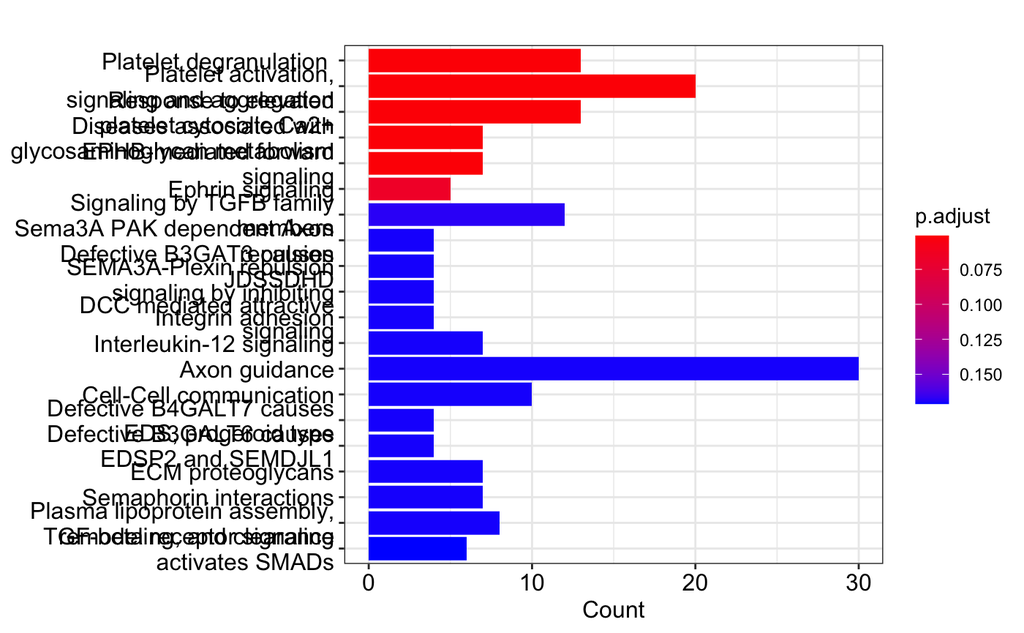

```r
#Bar plot
barplot(R_PA, showCategory = 20)
```

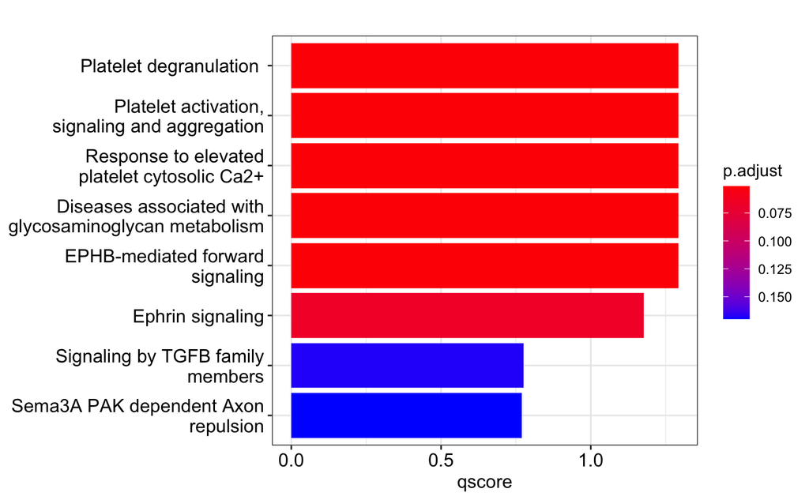

```r
mutate(R_PA, qscore = -log(p.adjust, base = 10)) |>
    barplot(x="qscore")
```

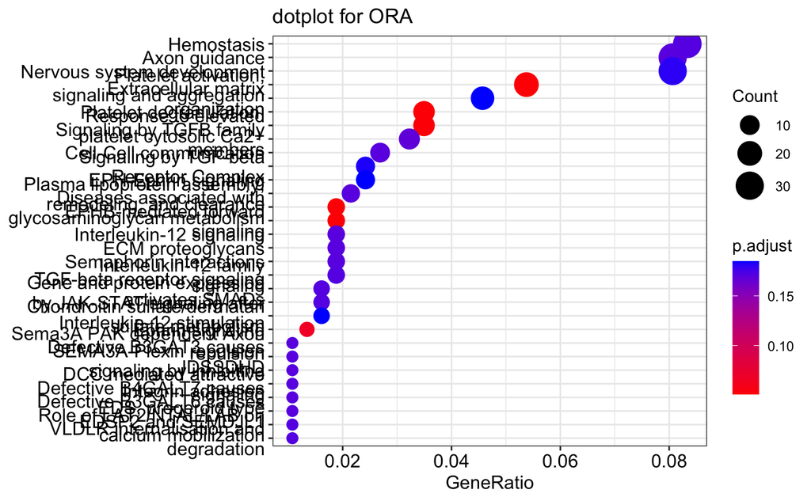

```r
#Dot plot
dotplot(R_PA, showCategory=30) +
  ggtitle("dotplot for ORA")
```

To do:

We cont with likelihood ratio test, ~ for the model use also other factors that influence- you need even number of comparison (6=6) variance partition package https://rdrr.io/bioc/variancePartition/f/inst/doc/variancePartition.pdf

doing heatmap using the genes (done)

age clust by similarity

- topGOtable
- pathways and functions - make a table